# CM515 Assignment 5

Gregory McKittrick

# Instructions

The aim of this assignment is to provide you with an opportunity to sharpen your skills in using ggplot(). While some of the plots you create may resemble those we covered in class, it is essential that they are original.

Rules for the Assignment:

1.All data sets except iris are fair game. That includes past data sets used in the class, sets built into R, your own data, and even online data.

2. All graphs must include axis labels, plot title, a theme of your choice, and a brief description/interpretation of the plot (2-3 sentences).

It’s worth noting that ggplot() is a widely-used tool, and there are numerous online resources available for you to explore. We strongly recommend that you take advantage of these resources to deepen your understanding of ggplot().

Knit the document into a PDF and submit it to Canvas by 02/28/2024 at 11:59 pm.

# 1. Make a Scatter Plot With Customized Point Size and Transparency (3pts)

Description and Interpretation: The plot shows the area of pores in 48 rock core cross-sections and the total perimeter of pores. Measurements are in pixels. In general, samples with greater area of pores also have greater perimeter of pores.

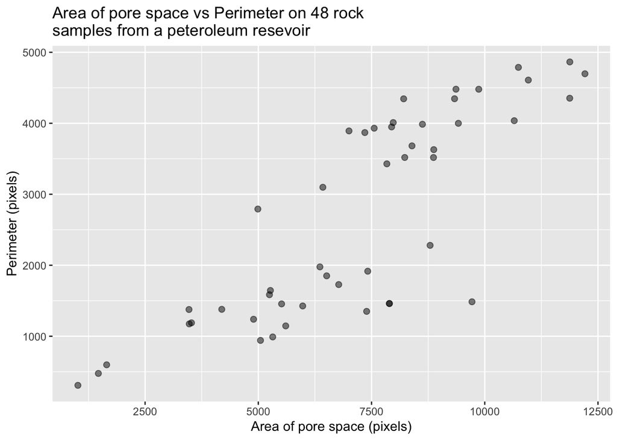

# 2. Fit a Line Through Your Scatter Plot From 1. (3pts)

Description and Interpretation:The plot shows the area of pores in 48 rock core cross-sections and the total perimeter of pores. Measurements are in pixels. In general, samples with greater area of pores also have greater perimeter of pores, the blue line demonstrates a good fit of the linear model to the data and positive relationship between the two variables.

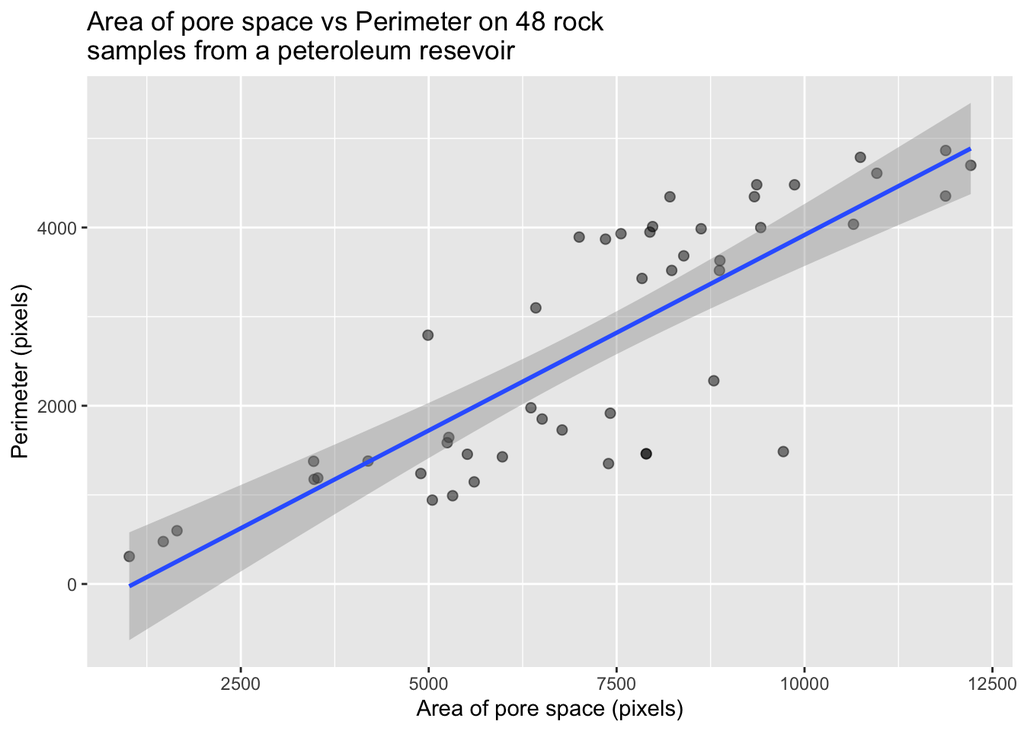

# 3. Set the transparency, shape, and color of your graph from 1 based on expressions. Scale the color. (3pts)

Description and Interpretation:

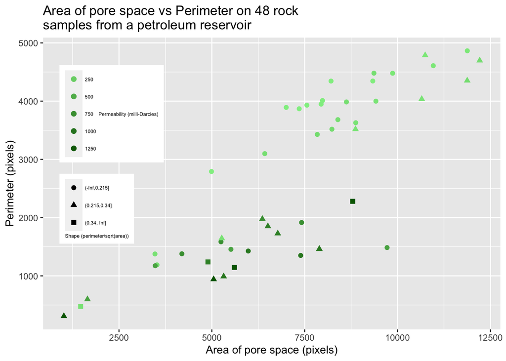

# 4. Make a Boxplot With Customized Boxplot Width (3pts)

Description and Interpretation: Box plot of body temperature measurements in celcius of beavers at two different days since the beginning of 1990 (December 12–13). Day 347 has a lower median body temperature than 367 and a closer grouping of measurments with less outliers.

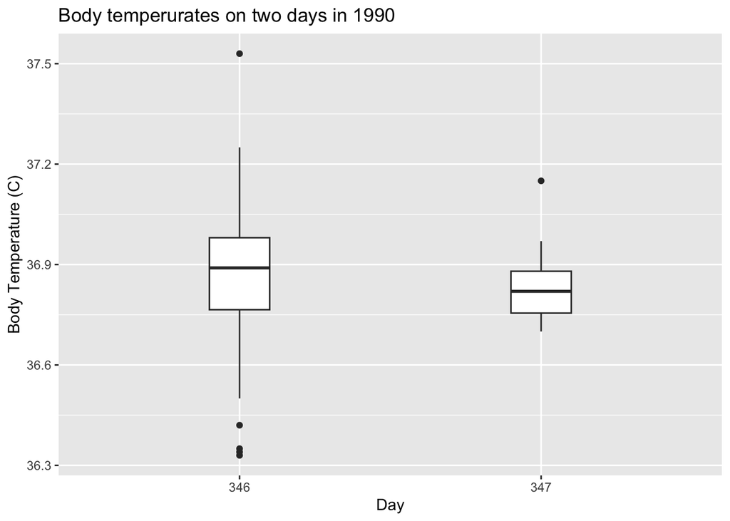

# 5. Overlay the Individual Points Over Your Box Plot From 3. and Adjust the Point Size and Transparency as Needed (3pts)

Description and Interpretation: Box plot of body temperature measurements in celcius of beavers at two different days since the beginning of 1990 (December 12–13). Day 347 has a lower median body temperature than 367 and a closer grouping of measurments with less outliers.

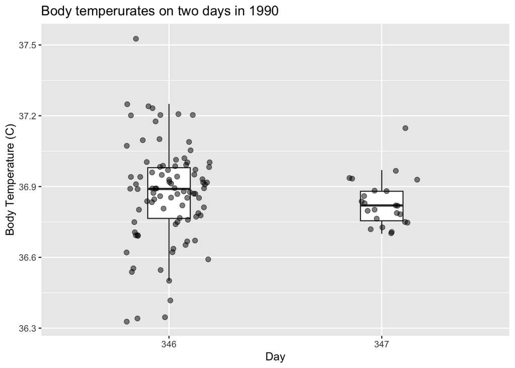

# 6. Make a plot and modify the scale in a beneficial way using scale_x_continuous(), scale_y_continuous(), and coordinate_cartesian(). Explain how your modifications to the scales improved the plot. (4pts)

Description and Interpretation: Scatter plot of horse power and miles per gallon from mtcars data set. In general, miles per gallon decreases as horsepower increases. Adding tick marks at every 5 mpg and ever 50 horsepower makes the values of points easier to determine. Additionally, selecting only data points close to the middle of the mpg and hp range eliminates data points outside of the typical car range, making a linear trend more apparnet.

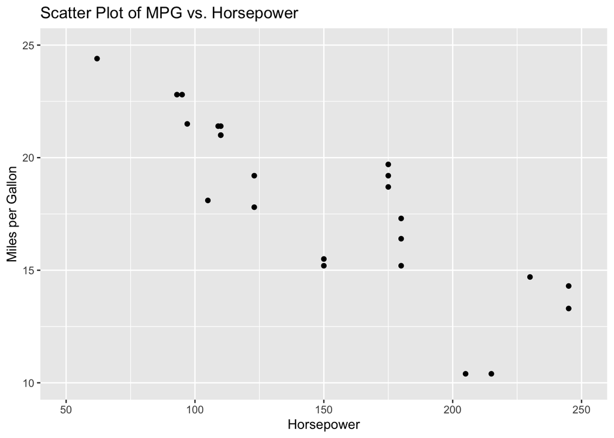

# 7. Make a New (don’t use any plots from 1-4) Plot with facet_wrap() (4pts)

Description and Interpretation:

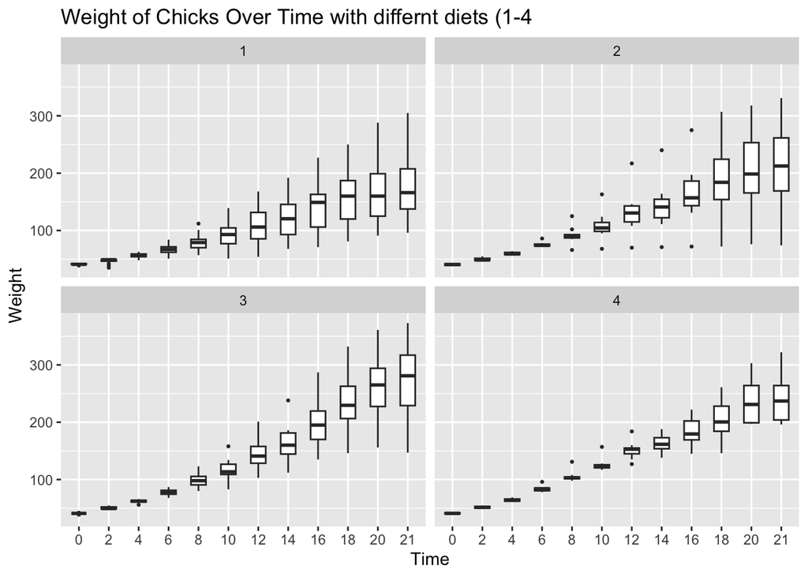

# 8. Using the plot from 5, scale the colors and reorder your facet to reverse order. (4pts)

Description and Interpretation:

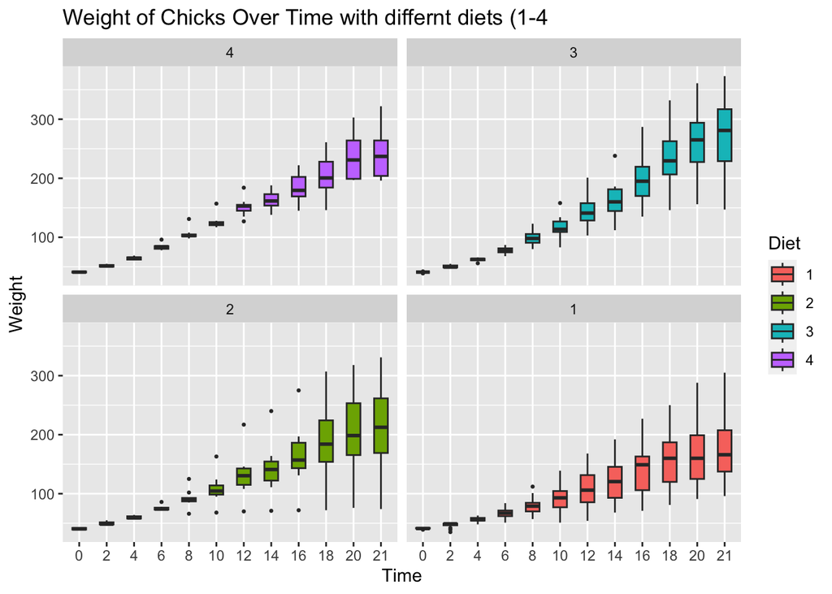

# 9. Make a Plot Using a Geometry That Was Not Covered in Class (4pts)

Description and Interpretation: Cleveland dot plot showing the range of horsepower for 4, 6, and 8 cylinder cars. There is more overlap between 6 and 8 cylinder hp than between 4 cylinders and 6.

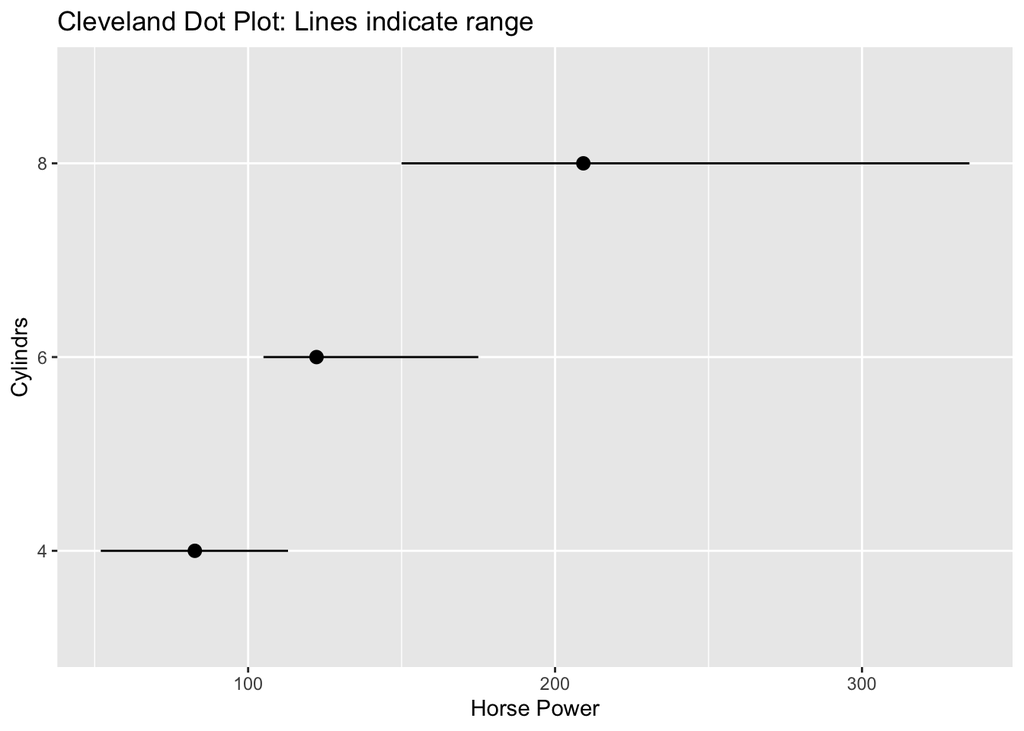

# 10. Make a Plot Using a ggplot Extension That Was Not Covered in Class. Explain what the extension does. (4pts)

Description and Interpretation: The beeswarm layout helps to avoid overlapping points and provides a clearer view of the distribution compared to a standard scatter plot.

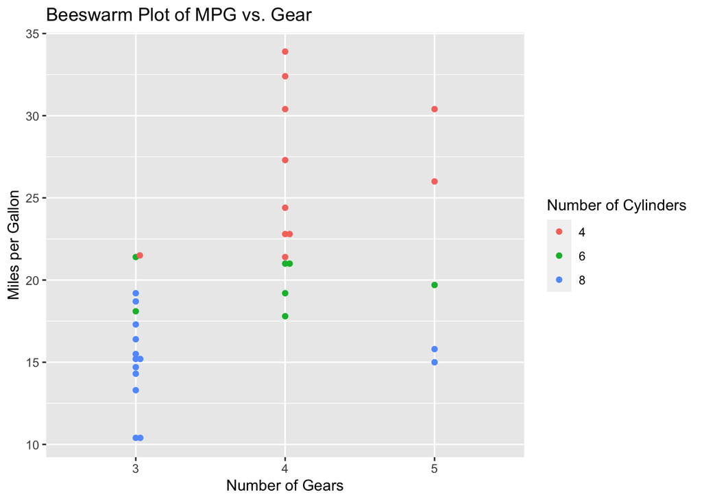

# Appendix

```r
knitr::opts_chunk$set(echo = F, message = F, warning = F)
####
#00#
####
library(knitr)
library(tidyverse)

####
#01#
####
data1 <- rock

P1 <- ggplot(
    data = data1,
    mapping = aes(x = area, y = peri)
)+
geom_point( size = 2, alpha = 0.5) +
labs(title = "Area of pore space vs Perimeter on 48 rock\nsamples from a peteroleum resevoir ", x = "Area of pore space (pixels)", y = "Perimeter (pixels)")
P1

####
#02#
####
P2 <- ggplot(
    data = data1,
    mapping = aes(x = area, y = peri)
)+
geom_point( size = 2, alpha = 0.5) +
  geom_smooth(method = lm) +
labs(title = "Area of pore space vs Perimeter on 48 rock\nsamples from a peteroleum resevoir ", x = "Area of pore space (pixels)", y = "Perimeter (pixels)")
P2

####
#03#
####

# Define cutoffs and corresponding shapes
cutoffs_for_graph <- c(-Inf, 0.21493, 0.33953, Inf)

P3 <- ggplot(
  data = data1,
  mapping = aes(x = area, y = peri, color = perm, shape = cut(shape, breaks = cutoffs_for_graph))
) +
  geom_point(size = 2, alpha = 1) +
 # geom_smooth(method = lm) +
  scale_color_gradient(low = "lightgreen", high = "darkgreen", name = "Permeability (milli-Darcies)") +
  labs(
    title = "Area of pore space vs Perimeter on 48 rock\nsamples from a petroleum reservoir",
    x = "Area of pore space (pixels)",
    y = "Perimeter (pixels)"
  ) +
  theme(
    legend.text = element_text(size = 5),  # Shrink the size of legend text
    legend.title = element_text(size = 5),  # Shrink the size of legend title
    legend.position = c(0.15, 0.6) #position them over the graph
  ) +
  guides(
    shape = guide_legend(
      title = "Shape (perimeter/sqrt(area))",
      title.position = "bottom",
      title.hjust = 0.1
    ),
    color = guide_legend(
      title.position = "right",
      title.hjust = 0.1
    )
  )

P3


####
#04#
####
data2 <- beaver1

P4 <- ggplot(data2, aes(x = as.factor(day), y = temp)) +
  geom_boxplot(width = 0.2) +  # Adjust width as needed
  ggtitle("Body temperurates on two days in 1990") +
  xlab("Day") +
  ylab("Body Temperature (C)")

P4

####
#05#
####
P5 <- ggplot(data2, aes(x = as.factor(day), y = temp)) +
  geom_boxplot(width = 0.2, outlier.shape = NA) +
  geom_jitter(width = 0.2, alpha = 0.5, size = 2) + # Adjust width as needed
  ggtitle("Body temperurates on two days in 1990") +
  xlab("Day") +
  ylab("Body Temperature (C)")

P5

####
#06#
####
data3 <- mtcars
p6 <- ggplot(data3, aes(x = hp, y = mpg)) +
  geom_point() +
  labs(x = "Horsepower", y = "Miles per Gallon") +
  ggtitle("Scatter Plot of MPG vs. Horsepower") +
  scale_x_continuous(limits = c(50, 400), breaks = seq(50, 400, by = 50)) +
  scale_y_continuous(limits = c(10, 35), breaks = seq(10, 35, by = 5))+
  coord_cartesian(xlim = c(50, 250), ylim = c(10, 25))
p6
#07#
####
data4 <- ChickWeight

p7 <- ggplot(data4, aes(x = as.factor(Time), y = weight)) +
  geom_boxplot(width = 0.5, outlier.size = 0.5 ) +
  labs(x = "Time", y = "Weight") +
  ggtitle("Weight of Chicks Over Time with differnt diets (1-4") +
  facet_wrap(~ Diet)

p7

#08#
####
p8 <- ggplot(data4, aes(x = as.factor(Time), y = weight, fill = Diet)) +
  geom_boxplot(width = 0.5, outlier.size = 0.5 ) +
  labs(x = "Time", y = "Weight") +
  ggtitle("Weight of Chicks Over Time with differnt diets (1-4") +
  scale_color_brewer( palette = "Dark2") +
  facet_wrap(~ factor(Diet, levels = rev(unique(ChickWeight$Diet))))

p8


####
#09#
####
data5 <- data3 %>%
  group_by(cyl) %>%
  summarise(Min = min(hp), Max= max(hp), Mean = mean(hp))

p9 <- ggplot(data5, aes(x = reorder(cyl, Mean, descending = T), y = Mean)) +
  geom_pointrange(aes(ymin = Min, ymax = Max)) +
  labs(title = "Cleveland Dot Plot: Lines indicate range",
       x = "Cylindrs", y = "Horse Power")+
  coord_flip()

p9
####
#10#
####
library(ggbeeswarm)

p10 <- ggplot(data3, aes(x = factor(gear), y = mpg, color = factor(cyl))) +
  geom_beeswarm() +
  labs(x = "Number of Gears", y = "Miles per Gallon") +
  ggtitle("Beeswarm Plot of MPG vs. Gear") +
  scale_color_discrete(name = "Number of Cylinders")

p10
```